# Mini-Project 03: Do Proportional Electoral College Allocations Yield a More Representative Presidency?

In this project, we’re crafting a political fact-check, one of the most defining formats of contemporary journalism. Our focus will be on examining whether the US Electoral College consistently skews election outcomes away from the popular vote. As we explore political data, we’ll also gain a deeper understanding of the workings of federal elections in the United States.

In this project, we’ll:

- Combine data from diverse government and academic sources
- Work with spatial data structures and formats
- Generate a variety of visualizations
- Utilize spatial and animated graphics to support our analysis

## **Project Setup and Preliminary Data Exploration**

**Import Libraries**

```r
# Load necessary packages
if (!require("sf")) install.packages("sf")
if (!require("httr")) install.packages("httr")
if (!require("tidyverse")) install.packages("tidyverse")
if (!require("dplyr")) install.packages("dplyr")
if (!require("ggplot2")) install.packages("ggplot2")
if (!require("gt")) install.packages("gt")
if (!require("gt")) install.packages("DT")

library(sf)
library(httr)
library(tidyverse)
library(dplyr)
library(ggplot2)
library(gt)
library(DT)
```

**Data I: US House Election Votes from 1976 to 2022 - Downloading the data**

The [MIT Election Data Science Lab](https://electionlab.mit.edu/) collects votes from all biennial congressional races in all 50 states [here](https://dataverse.harvard.edu/dataset.xhtml?persistentId=doi:10.7910/DVN/IG0UN2). Download this data as a CSV file using your web browser.

**Downloading the data**

```r
president_data_path <- "/Users/valeriafrolova/STA9750-2024-FALL/docs/1976-2020-president.csv"
house_data_path <- "/Users/valeriafrolova/STA9750-2024-FALL/docs/1976-2022-house.csv"

# Load the datasets
president_data <- read.csv(president_data_path)
house_data <- read.csv(house_data_path)
```

**Data II: Congressional Boundary Files 1976 to 2012**

Jeffrey B. Lewis, Brandon DeVine, Lincoln Pritcher, and Kenneth C. Martis have created *shapefiles* for all US congressional districts from 1789 to 2012; they generously make these available [here](https://cdmaps.polisci.ucla.edu/).

**Task 1: Download Congressional Shapefiles 1976-2012**

**Downloading the Shapefiles**

```r
# Create directory for shapefiles
dir.create("data/shapefiles", showWarnings = FALSE, recursive = TRUE)

# Function to download shapefiles systematically
download_shapefiles <- function(start, end, base_url) {
  for (session in start:end) {
    file_name <- paste0("districts", sprintf("%03d", session), ".zip")
    url <- paste0(base_url, file_name)
    destfile <- file.path("data/shapefiles", file_name)

    if (!file.exists(destfile)) {
      GET(url, write_disk(destfile, overwrite = TRUE))
      message(paste("Downloaded:", file_name))
    } else {
      message(paste("File already exists:", file_name))
    }
  }
}

# Define the base URL and download the files
base_url <- "https://cdmaps.polisci.ucla.edu/shp/"
download_shapefiles(94, 112, base_url)

# Create directory for shapefiles if it doesn't exist
dir.create("data/census_shapefiles", showWarnings = FALSE, recursive = TRUE)
```

**Data III: Congressional Boundary Files 2014 to Present**

**Task 2: Download Congressional Shapefiles 2014-2022**

**Downloading the Shapefiles**

```r
# Load necessary library
library(httr)

# Function to map years to Congress numbers
get_congress_number <- function(year) {
  if (year %in% c(2014, 2015)) {
    return(114)
  } else if (year %in% c(2016, 2017)) {
    return(115)
  } else if (year >= 2018 && year <= 2022) {
    return(116)
  } else {
    stop("Congress number for the given year is not defined.")
  }
}

# Function to download shapefiles systematically
download_shapefiles_census <- function(years, dest_dir) {
  # Create the destination directory if it doesn't exist
  if (!dir.exists(dest_dir)) {
    dir.create(dest_dir, recursive = TRUE)
  }

  for (year in years) {
    congress <- get_congress_number(year)

    # Construct the URL and file name
    url <- sprintf("https://www2.census.gov/geo/tiger/TIGER%d/CD/tl_%d_us_cd%d.zip", year, year, congress)
    file_name <- sprintf("tl_%d_us_cd%d.zip", year, congress)
    destfile <- file.path(dest_dir, file_name)

    # Check if the file already exists
    if (!file.exists(destfile)) {
      # Download the file
      GET(url, write_disk(destfile, overwrite = TRUE))
      message(paste("Downloaded:", file_name))
    } else {
      message(paste("File already exists:", file_name))
    }
  }
}

# Define the years and destination directory
years <- 2014:2022
dest_dir <- "data/census_shapefiles"

# Download the shapefiles
download_shapefiles_census(years, dest_dir)
```

**Task 3: Exploration of Vote Count Data**

1. **Which states have gained and lost the most seats in the US House of Representatives between 1976 and 2022?**

Texas gained the biggest amount of votes, while New York lost the most of seats.

**Code: Gained vs Lost**

```r
house_seats <- house_data |>
  filter(year %in% c(1976, 2022)) |>
  distinct(year, state, district) |>
  group_by(year, state) |>
  summarise(seat_count = n(), .groups = "drop")
print(house_seats)
```

```
# A tibble: 100 × 3
    year state       seat_count
   <int> <chr>            <int>
 1  1976 ALABAMA              7
 2  1976 ALASKA               1
 3  1976 ARIZONA              4
 4  1976 ARKANSAS             4
 5  1976 CALIFORNIA          43
 6  1976 COLORADO             5
 7  1976 CONNECTICUT          6
 8  1976 DELAWARE             1
 9  1976 FLORIDA             15
10  1976 GEORGIA             10
# ℹ 90 more rows
```

**Code: Gained vs Lost**

```r
seat_changes <- house_seats |>
  pivot_wider(names_from = year, values_from = seat_count, names_prefix = "year_") |>
  mutate(seat_change = year_2022 - year_1976) |>
  arrange(desc(seat_change))

max_gain <- seat_changes |>
  filter(seat_change == max(seat_change, na.rm = TRUE))

max_loss <- seat_changes |>
  filter(seat_change == min(seat_change, na.rm = TRUE))

print(max_gain)
```

```
# A tibble: 1 × 4
  state year_1976 year_2022 seat_change
  <chr>     <int>     <int>       <int>
1 TEXAS        24        38          14
```

**Code: Gained vs Lost**

```r
print(max_loss)
```

```
# A tibble: 1 × 4
  state    year_1976 year_2022 seat_change
  <chr>        <int>     <int>       <int>
1 NEW YORK        39        26         -13
```

**Code: Gained vs Lost**

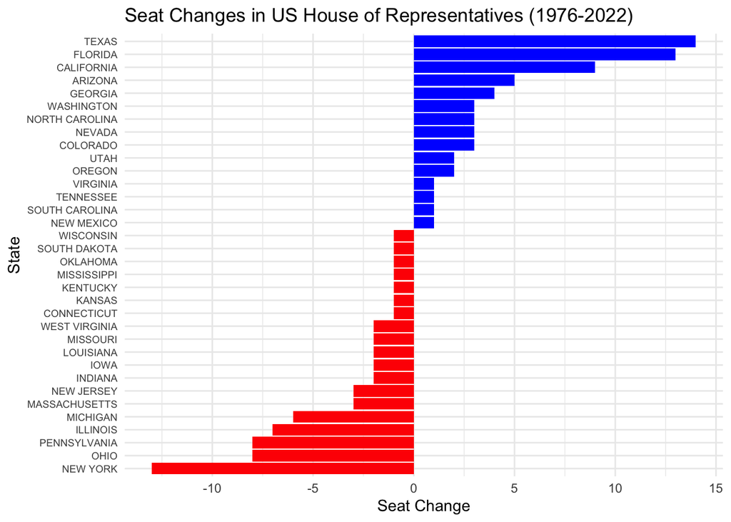

```r
#plot
state_seat_changes <- seat_changes |>
  filter(seat_change != 0) |>
  arrange(seat_change) |>
  mutate(state = factor(state, levels = state))

# Create the horizontal bar plot
ggplot(state_seat_changes, aes(x = seat_change, y = state, fill = seat_change > 0)) +
  geom_bar(stat = 'identity') +
  scale_fill_manual(values = c("red", "blue"), guide = FALSE) +
  labs(
    title = "Seat Changes in US House of Representatives (1976-2022)",
    x = "Seat Change",
    y = "State"
  ) +
  theme_minimal() +
  theme(axis.text.y = element_text(size = 7))
```

The chart shows which states gained or lost seats over the period, with positive changes in blue bars and negative changes in red bars. The length of each bar represents the number of seats gained or lost. Texas has the largest gain, while New York has the largest loss over this period.

2. **Are there any elections in our data where the election would have had a different outcome if the “fusion” system was not used and candidates only received the votes their received from their “major party line” (Democrat or Republican) and not their total number of votes across all lines?**

New York State has a unique **“fusion”** voting system where one candidate can appear on multiple “lines” on the ballot and their vote counts are totaled. For instance, in 2022, Jerrold Nadler appeared on both the Democrat and Working Families party lines for NYS’ 12th Congressional District. He received 200,890 votes total (184,872 as a Democrat and 16,018 as WFP), easily defeating Michael Zumbluskas, who received 44,173 votes across three party lines (Republican, Conservative, and Parent).

Fusion system plays important role, as one candidate can get votes from several parties. You can find below the outcomes comparison for non-fusion system, that proves that actual winners for fusion system are not having the same winning status for non-fusion.

**Fusion vs. Non-Fusion Votes Comparison**

```r
# Step 1: Filter for New York State and select relevant columns
ny_house_data <- house_data |>
  filter(state == "NEW YORK") |>
  dplyr::select(year, district, candidate, party, candidatevotes)

# Step 2: Determine actual winners (with fusion votes)
actual_winners <- ny_house_data |>
  group_by(year, district, candidate) |>
  summarise(total_votes = sum(candidatevotes, na.rm = TRUE)) |>
  ungroup() |>
  group_by(year, district) |>
  slice_max(total_votes, n = 1, with_ties = FALSE) |>
  select(year, district, actual_winner = candidate)

# Step 3: Determine hypothetical winners (without fusion votes)
hypothetical_winners <- ny_house_data |>
  filter(party %in% c("DEMOCRAT", "REPUBLICAN")) |>
  group_by(year, district, candidate) |>
  summarise(total_votes = sum(candidatevotes, na.rm = TRUE)) |>
  ungroup() |>
  group_by(year, district) |>
  slice_max(total_votes, n = 1, with_ties = FALSE) |>
  dplyr::select(year, district, hypothetical_winner = candidate)

# Step 4: Compare actual and hypothetical winners
different_outcomes <- actual_winners |>
  left_join(hypothetical_winners, by = c("year", "district")) |>
  filter(actual_winner != hypothetical_winner)

# TABLE VIEW
rownames(different_outcomes) <- NULL
different_outcomes <- different_outcomes |>
  ungroup()
library(tibble)
different_outcomes <- as_tibble(different_outcomes)

different_outcomes |>
  select(year, district, actual_winner, hypothetical_winner) |>
  gt() |>
  tab_header(
    title = "Fusion vs. Non-Fusion Vote Outcomes in New York",
    subtitle = "Comparison of Actual Winners vs. Hypothetical Winners"
  ) |>
  cols_label(
    year = "Year",
    district = "District",
    actual_winner = "Actual Winner",
    hypothetical_winner = "Hypothetical Winner"
  ) |>
  cols_align(
    align = "center",
    columns = everything()
  ) |>
  tab_options(
    table.font.size = 12,
    heading.align = "center"
  ) |>
  tab_style(
    style = cell_fill(color = "lightgray"),
    locations = cells_body(
      columns = everything(),
      rows = seq(1, nrow(different_outcomes), by = 2)
    )
  )
```

Fusion vs. Non-Fusion Vote Outcomes in New York

Comparison of Actual Winners vs. Hypothetical Winners

| Year | District | Actual Winner | Hypothetical Winner |
| --- | --- | --- | --- |
| 1976 | 29 | EDWARD W PATTISON | JOSEPH A MARTINO |
| 1980 | 3 | GREGORY W CARMAN | JEROME A AMBRO JR |
| 1980 | 6 | JOHN LEBOUTILLIER | LESTER L WOLFF |
| 1984 | 20 | JOSEPH J DIOGUARDI | OREN J TEICHER |
| 1986 | 27 | GEORGE C WORTLEY | ROSEMARY S POOLER |
| 1992 | 3 | PETER T KING | STEVE A ORLINS |
| 1994 | 1 | MICHAEL P FORBES | GEORGE J HOCHBRUECKNER |
| 1996 | 1 | MICHAEL P FORBES | NORA L BREDES |
| 1996 | 30 | JACK QUINN | FRANCIS J PORDUM |
| 2006 | 25 | JAMES T WALSH | DAN MAFFEI |
| 2006 | 29 | JOHN R "RANDY" KUHL JR | ERIC J MASSA |
| 2010 | 13 | MICHAEL G GRIMM | MICHAEL E MCMAHON |
| 2010 | 19 | NAN HAYMORTH | JOHN J HALL |
| 2010 | 24 | RICHARD L HANNA | MICHAEL A ARCURI |
| 2010 | 25 | ANN MARIE BUERKLE | DANIEL B MAFFEI |
| 2012 | 27 | CHRIS COLLINS | KATHLEEN C HOCHUL |
| 2018 | 1 | LEE M ZELDIN | PERRY GERSHON |
| 2018 | 24 | JOHN M KATKO | DANA BALTER |
| 2018 | 27 | CHRIS COLLINS | NATHAN D MCMURRAY |
| 2022 | 4 | ANTHONY P D’ESPOSITO | LAURA A GILLEN |
| 2022 | 17 | MICHAEL V LAWLER | SEAN PATRICK MALONEY |
| 2022 | 22 | BRANDON M WILLIAMS | FRANCIS CONOLE |

Yes, the table shows instances where the election outcome would indeed have been different if New York’s “fusion voting” system was not in place. In a fusion system, candidates are allowed to run on multiple party lines, and their votes from all party lines are combined. However, if candidates were only counted for their “major party line” (Democrat or Republican), some races would have had different winners, as indicated in the table.

3. **Do presidential candidates tend to run ahead of or run behind congressional candidates in the same state?**

Presidential candidates typically receive more votes than their party’s congressional candidates in the same election year. However, the data shows notable exceptions: in 1992, both Democratic and Republican presidential candidates received fewer votes than their congressional counterparts. Additionally, in years like 1976, 1980, 1984, 1988, and 1996, only one party’s presidential candidate received more votes than their House candidates, indicating that voter focus sometimes shifts depending on the election year and party dynamics. Overall, while presidential candidates tend to run ahead, there are specific years where this trend does not hold across both parties.

**Presidential vs. Congressional Votes**

```r
# Aggregate House Votes by Year and Party
house_votes_yearly <- house_data |>
  group_by(year, party) |>
  summarise(total_votes_house = sum(candidatevotes, na.rm = TRUE)) |>
  ungroup()

# Aggregate Presidential Votes by Year and Party
pres_votes_yearly <- president_data |>
  group_by(year, party_detailed) |>
  summarise(
    total_votes_pres = sum(candidatevotes, na.rm = TRUE),
    candidate = first(candidate)
  ) |>
  ungroup()

# Rename 'party_detailed' to 'party' for consistency
pres_votes_yearly <- pres_votes_yearly |>
  rename(party = party_detailed)

# Merge Presidential and House Data
combined_votes_yearly <- pres_votes_yearly |>
  left_join(house_votes_yearly, by = c("year", "party")) |>
  drop_na()

# Ensure 'total_votes_house' is an integer
combined_votes_yearly <- combined_votes_yearly |>
  mutate(total_votes_house = as.integer(total_votes_house))

# **Filter to Show Only Instances Where Presidential Votes > House Votes**
filtered_votes_yearly <- combined_votes_yearly |>
  filter(
    party != "",
    candidate != "",
    party %in% c("DEMOCRAT", "REPUBLICAN"),
    total_votes_pres > total_votes_house  # New filter condition
  ) |>
  select(
    Year = year,
    Party = party,
    Presidential_Candidate = candidate,
    Presidential_Votes = total_votes_pres,
    House_Votes = total_votes_house
  ) |>
  drop_na()

filtered_votes_yearly |>
  gt()
```

| Year | Party | Presidential_Candidate | Presidential_Votes | House_Votes |
| --- | --- | --- | --- | --- |
| 1976 | REPUBLICAN | FORD, GERALD | 38870893 | 31194553 |
| 1980 | REPUBLICAN | REAGAN, RONALD | 43642639 | 37068793 |
| 1984 | REPUBLICAN | REAGAN, RONALD | 54166829 | 38540768 |
| 1988 | REPUBLICAN | BUSH, GEORGE H.W. | 48642640 | 37015826 |
| 1996 | DEMOCRAT | CLINTON, BILL | 47295351 | 43598585 |
| 2000 | DEMOCRAT | GORE, AL | 49662314 | 45177356 |
| 2000 | REPUBLICAN | BUSH, GEORGE W. | 50311372 | 46750176 |
| 2004 | DEMOCRAT | KERRY, JOHN | 57449547 | 51345579 |
| 2004 | REPUBLICAN | BUSH, GEORGE W. | 61872711 | 55723203 |
| 2008 | DEMOCRAT | OBAMA, BARACK H. | 69338846 | 63272262 |
| 2008 | REPUBLICAN | MCCAIN, JOHN | 59613835 | 51952377 |
| 2012 | DEMOCRAT | OBAMA, BARACK H. | 64205850 | 58503445 |
| 2012 | REPUBLICAN | ROMNEY, MITT | 60670117 | 57977915 |
| 2016 | DEMOCRAT | CLINTON, HILLARY | 65677288 | 60957891 |
| 2020 | DEMOCRAT | BIDEN, JOSEPH R. JR | 81268908 | 76879506 |
| 2020 | REPUBLICAN | TRUMP, DONALD J. | 74216146 | 72671813 |

**That is, does a Democratic candidate for president tend to get more votes in a given state than all Democratic congressional candidates in the same state?**

The data indicates that a Democratic candidate for president often receives more votes than all Democratic congressional candidates combined in the same state. Specifically, in 2020, in multiple states, Joe Biden received more votes than the total votes for Democratic congressional candidates. This suggests that he was relatively more popular compared to his party’s congressional candidates in those states.

However, this trend is not consistent across all elections. For instance, in 1976, Jimmy Carter received fewer votes than the total Democratic congressional candidates in multiple states, indicating that he was relatively less popular compared to his party’s congressional candidates at that time.

**Democrat Presidential vs. Congressional Votes**

```r
# Filter for only Democratic candidates
combined_votes_democrats <- combined_votes_yearly |>
  filter(party == "DEMOCRAT")

pres_outperformed_house_democrats <- combined_votes_democrats |>
  filter(total_votes_pres > total_votes_house)

house_outperformed_house_democrats <- combined_votes_democrats |>
  filter(total_votes_house > total_votes_pres)

#table view
pres_outperformed_house_democrats |>
  select(
    Year = year,
    State = state,
    Presidential_Candidate = candidate,
    Presidential_Votes = total_votes_pres,
    House_Votes = total_votes_house
  ) |>
  arrange(desc(Year), State) |>  # Sort by Year descending and State
  head(10) |>
  gt() |>
  fmt_number(
    columns = c(Presidential_Votes, House_Votes),
    decimals = 0,
    use_seps = TRUE
  )
```

[output not shown]

**Does this trend differ over time?**

This chart displays the total votes cast for Presidential candidates versus House candidates over time, showing how voter turnout or engagement has changed across these two types of elections.

Both presidential and House votes have steadily increased over time, indicating a rise in voter turnout or engagement across the years. This is likely due to population growth and possibly higher political engagement in more recent elections.

In many election cycles, the total votes for Presidential candidates slightly exceed those for House candidates, as shown by the blue line generally trending higher than the red line. In 1994-1997 higher volume of House votes over Presidential can be observed.

**Presidential vs. Congressional Votes Comparison**

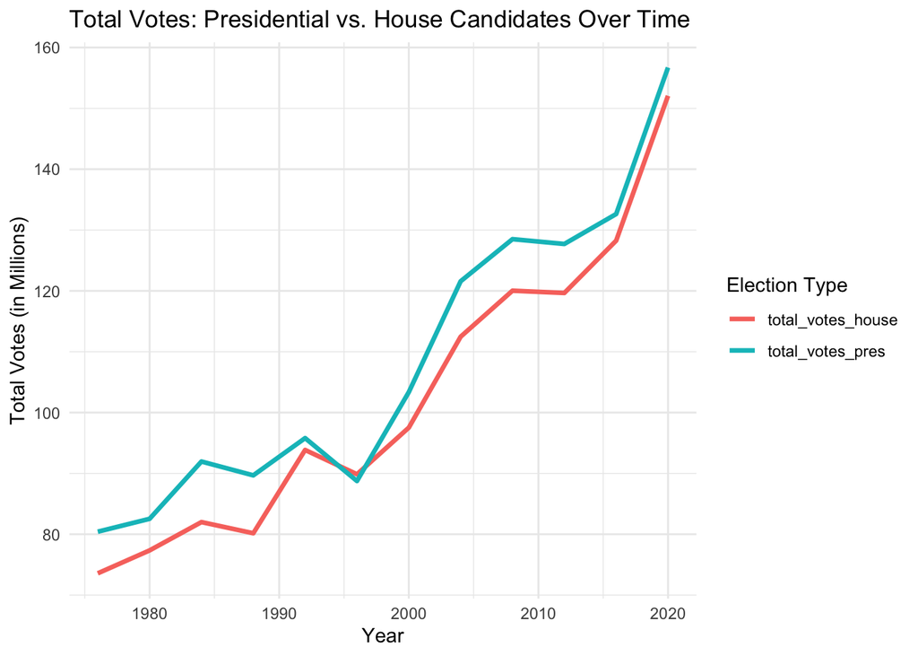

```r
state_totals <- combined_votes_yearly |>
  group_by(state) |>
  summarise(
    total_votes_pres = sum(total_votes_pres, na.rm = TRUE),
    total_votes_house = sum(total_votes_house, na.rm = TRUE),
    vote_difference = sum(total_votes_pres, na.rm = TRUE) - sum(total_votes_house, na.rm = TRUE)
  ) |>
  ungroup()

yearly_totals <- combined_votes_yearly |>
  group_by(year) |>
  summarise(
    total_votes_pres = sum(total_votes_pres, na.rm = TRUE),
    total_votes_house = sum(total_votes_house, na.rm = TRUE)
  ) |>
  ungroup()

yearly_totals_long <- yearly_totals |>
  pivot_longer(cols = c(total_votes_pres, total_votes_house), names_to = "election_type", values_to = "total_votes")

#plotting
# Compare total votes over time
ggplot(yearly_totals_long, aes(x = year, y = total_votes / 1e6, color = election_type)) +
    geom_line(size = 1.2) +
    labs(
        title = "Total Votes: Presidential vs. House Candidates Over Time",
        x = "Year",
        y = "Total Votes (in Millions)",
        color = "Election Type"
    ) +
    theme_minimal()
```

**Does it differ across states or across parties?**

The chart displays the vote difference between presidential and House candidates by state, with each state showing whether presidential candidates received more or fewer votes than House candidates. Positive values (teal bars): indicate states where presidential candidates received more votes than House candidates. Negative values (red bars): indicate states where House candidates received more votes than presidential candidates.

**Presidential vs. Congressional Votes Comparison by State**

[figure not shown]

```r
library(scales)

state_totals <- state_totals |>
  mutate(vote_difference = total_votes_pres - total_votes_house)

# Plot vote differences by state
ggplot(state_totals, aes(x = reorder(state, vote_difference), y = vote_difference, fill = vote_difference > 0)) +
  geom_col(show.legend = FALSE) +
  coord_flip() +
  labs(
    title = "Vote Difference by State: Presidential vs. House Candidates",
    x = "State",
    y = "Vote Difference (Presidential - House)"
  ) +
  scale_y_continuous(labels = label_comma()) +
  theme_minimal() +
  theme(
    axis.text.y = element_text(size = 5, vjust = 0.3, margin = margin(t = 4, b = 4)) # Increase top and bottom margins
  )
```

**Are any presidents particularly more or less popular than their co-partisans?**

Candidates such as Ronald Reagan, George W. Bush, Bill Clinton, and Barack Obama have positive vote differences, meaning they received significantly more votes than their congressional counterparts. This suggests these presidents were particularly popular within their states compared to their co-partisan congressional candidates.

In contrast, some entries show negative vote differences, particularly with candidates like Walter Mondale and Jimmy Carter. This suggests these candidates received fewer votes than their party’s congressional candidates in those states, indicating they may have been less popular relative to their co-partisan representatives.

**Presidential vs. Congressional Votes Comparison by Presidents**

[figure not shown]

```r
pres_total_votes <- pres_votes_yearly |>
  group_by(year, party, candidate) |>
  summarise(total_votes_pres = sum(total_votes_pres, na.rm = TRUE)) |>
  ungroup()

house_total_votes <- house_votes_yearly |>
  group_by(year, party) |>
  summarise(total_votes_house = sum(total_votes_house, na.rm = TRUE)) |>
  ungroup()

combined_votes <- pres_total_votes |>
  left_join(house_total_votes, by = c("year", "party")) |>
  drop_na()
# Calculate the vote difference for each president compared to House candidates of the same party
combined_votes <- combined_votes |>
  mutate(vote_difference = total_votes_pres - total_votes_house)

# Filter data to include only rows with vote differences greater than 300,000
filtered_votes <- combined_votes |>
  filter(abs(vote_difference) > 300000)

# Plot the filtered data
ggplot(filtered_votes, aes(x = reorder(candidate, vote_difference), y = vote_difference, fill = vote_difference > 0)) +
  geom_col(show.legend = FALSE) +
  coord_flip() +
  labs(
    title = "Vote Difference by President(Vote Difference > 100,000)",
    x = "President",
    y = "Vote Difference (Presidential - House)"
  ) +
  scale_y_continuous(labels = scales::label_comma()) +
  theme_minimal() +
  theme(
    axis.text.y = element_text(size = 6, vjust = 0.5, margin = margin(t = 6, b = 8)) # Increase spacing for candidate names
  )
```

Shapefiles - Import and Plotting

**Task 4: Automate Zip File Extraction**

```r
# Load necessary library
library(sf)

# Create a global list to store the loaded shapefiles to avoid re-loading
shapefile_cache <- list()

# Function to load shapefiles from zip archives within a specified directory
extract_and_load_shapefiles <- function(directory_path) {

  # Get a list of all zip files within the directory
  zip_archives <- list.files(directory_path, pattern = "\\.zip$", full.names = TRUE)

  for (archive_path in zip_archives) {
    # Create a temporary directory for file extraction
    temp_dir <- tempdir()
    unzip(archive_path, exdir = temp_dir)

    # Identify shapefiles in the extracted contents
    shp_files <- list.files(temp_dir, pattern = "\\.shp$", full.names = TRUE, recursive = TRUE)

    for (file_path in shp_files) {
      shp_filename <- basename(file_path)

      # Only read the shapefile if it hasn't been loaded before
      if (!shp_filename %in% names(shapefile_cache)) {
        tryCatch({
          # Read the shapefile and add it to the cache
          shape_data <- st_read(file_path, quiet = TRUE)
          shapefile_cache[[shp_filename]] <- shape_data
        }, error = function(err) {
          message("Error reading file:", file_path, " - ", err$message)
        })
      }
    }
  }

  # Return the list containing loaded shapefiles
  return(shapefile_cache)
}

# Specify the directory containing the shapefile zip files
shapefile_directory <- "data/shapefiles"

# Load shapefiles from the specified directory
shapefile_cache <- extract_and_load_shapefiles(shapefile_directory)
```

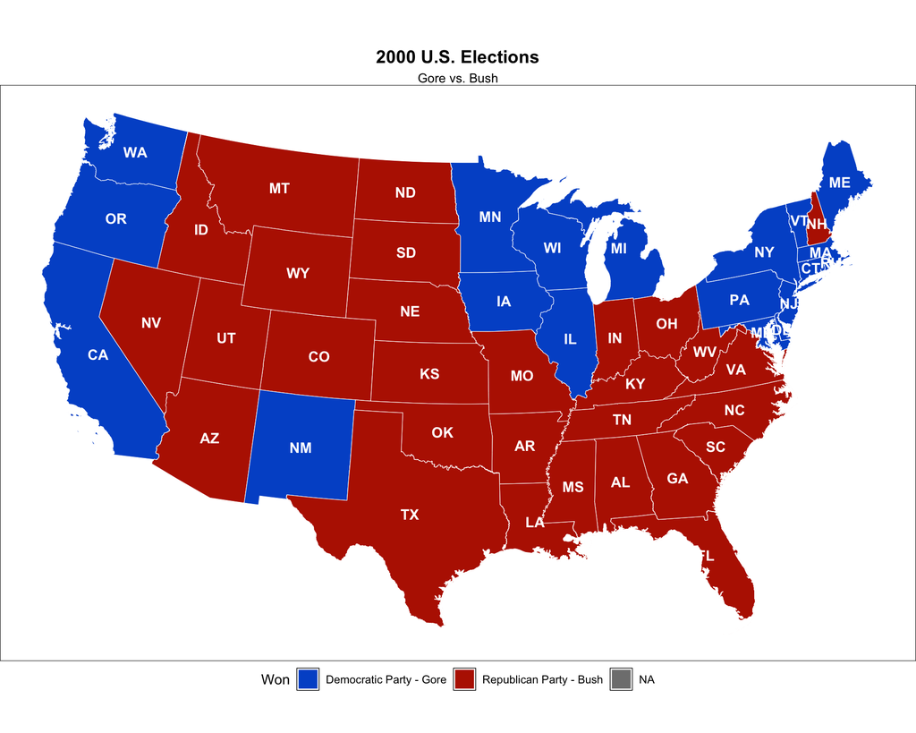

```r
# Load the election
election_data <- read.csv("/Users/valeriafrolova/STA9750-2024-FALL/docs/1976-2020-president.csv")

# Filter data for the 2000 presidential election
election_2000 <- election_data %>%
  filter(year == 2000, office == "US PRESIDENT")

# Determine the winning party per state
state_winners <- election_2000 %>%
  group_by(state, state_po) %>%
  summarise(winning_party = party_simplified[which.max(candidatevotes)]) %>%
  ungroup()

# Load the US shapefile
us_states <- shapefile_cache[["districts106.shp"]]


# Optional: Filter out territories if needed
us_states <- us_states %>%
  filter(!STATENAME %in% c("Alaska", "Hawaii", "Puerto Rico"))
state_abbreviations <- data.frame(
  STATENAME = c("Alabama", "Alaska", "Arizona", "Arkansas", "California", "Colorado", "Connecticut", "Delaware",
                "Florida", "Georgia", "Hawaii", "Idaho", "Illinois", "Indiana", "Iowa", "Kansas", "Kentucky",
                "Louisiana", "Maine", "Maryland", "Massachusetts", "Michigan", "Minnesota", "Mississippi",
                "Missouri", "Montana", "Nebraska", "Nevada", "New Hampshire", "New Jersey", "New Mexico",
                "New York", "North Carolina", "North Dakota", "Ohio", "Oklahoma", "Oregon", "Pennsylvania",
                "Rhode Island", "South Carolina", "South Dakota", "Tennessee", "Texas", "Utah", "Vermont",
                "Virginia", "Washington", "West Virginia", "Wisconsin", "Wyoming"),
  state_po = c("AL", "AK", "AZ", "AR", "CA", "CO", "CT", "DE", "FL", "GA", "HI", "ID", "IL", "IN", "IA", "KS",
               "KY", "LA", "ME", "MD", "MA", "MI", "MN", "MS", "MO", "MT", "NE", "NV", "NH", "NJ", "NM", "NY",
               "NC", "ND", "OH", "OK", "OR", "PA", "RI", "SC", "SD", "TN", "TX", "UT", "VT", "VA", "WA", "WV",
               "WI", "WY")
)

# Join the state abbreviations to the filtered shapefile data
us_states_with_abbrev <- us_states %>%
  left_join(state_abbreviations, by = "STATENAME")

# Join election results data to add information on the winning party by state
map_data <- us_states_with_abbrev %>%
  left_join(state_winners, by = "state_po")

# Define a bold color scheme for Republican and Democratic states
party_color_map <- c(
  "REPUBLICAN" = "#B82100",  # Bold red for Republicans
  "DEMOCRAT" = "#0057CE"     # Bold blue for Democrats
)

# Ensure geometries are valid before aggregating
us_states_valid <- us_states_with_abbrev %>%
  st_make_valid()

# Join election results data and aggregate to state level
state_map_data <- us_states_valid %>%
  left_join(state_winners, by = "state_po") %>%
  group_by(state_po, winning_party) %>%
  summarise(geometry = st_union(geometry), .groups = "drop") |> # Combine geometries to get state boundaries only
  st_as_sf() %>%
  st_transform(crs = 5070)  # Albers Equal Area projection for the U.S.

# Calculate centroids for placing state labels in the center of each state
state_centroids <- st_centroid(state_map_data)

state_centroids <- state_centroids %>%
  mutate(label = state_po)

# Create the map plot
ggplot(data = state_map_data) +
  geom_sf(aes(fill = winning_party), color = "white", size = 0.6) +  # Thicker white borders for states
  scale_fill_manual(
    values = party_color_map,
    name = "Won",  # Legend title
    labels = c("Democratic Party - Gore", "Republican Party - Bush")  # Explicitly label colors in the legend
  ) +
  geom_text(data = state_centroids, aes(geometry = geometry, label = state_po),
            size = 4, color = "white", fontface = "bold", stat = "sf_coordinates") +  # Place single abbreviation at the center
  labs(
    title = "2000 U.S. Elections",
    subtitle = "Gore vs. Bush"
  ) +
  theme_void() +  # Remove axes, gridlines, and background for a cleaner look
  theme(
    legend.position = "bottom",  # Place legend at the bottom for clear interpretation
    plot.title = element_text(face = "bold", size = 14, hjust = 0.5),
    plot.subtitle = element_text(size = 10, hjust = 0.5),
    panel.border = element_blank(),
    panel.background = element_rect(fill = "transparent")
  )
```

**Task 6: Faceted Map**

**Task 6: Faceted Map**

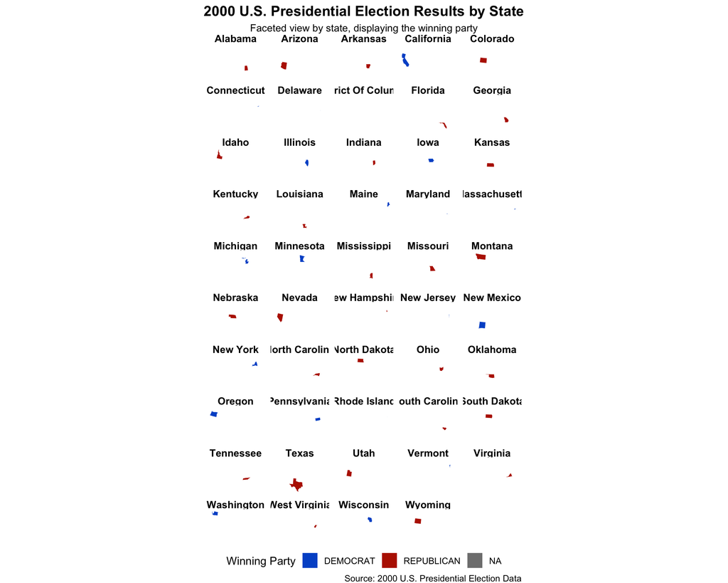

```r
# Ensure STATENAME is present in state_map_data
state_map_data <- us_states_valid |>
  left_join(state_winners, by = "state_po") |>
  group_by(state_po, winning_party, STATENAME) |>
  summarise(geometry = st_union(geometry), .groups = "drop") |> # Combine geometries to get state boundaries only
  st_as_sf() %>%
  st_transform(crs = 5070)  # Albers Equal Area projection for the U.S.

# Faceted Map Plot
ggplot(data = state_map_data) +
  geom_sf(aes(fill = winning_party), color = "white", size = 0.4) +
  scale_fill_manual(values = party_color_map, name = "Winning Party") +
  labs(
    title = "2000 U.S. Presidential Election Results by State",
    subtitle = "Faceted view by state, displaying the winning party",
    caption = "Source: 2000 U.S. Presidential Election Data"
  ) +
  theme_void() +
  theme(
    strip.text = element_text(face = "bold", size = 10),
    legend.position = "bottom",
    plot.title = element_text(hjust = 0.5, face = "bold", size = 14),
    plot.subtitle = element_text(hjust = 0.5, size = 10)
  ) +
  facet_wrap(~STATENAME, ncol = 5)
```

**Task 7: Evaluating Fairness of ECV Allocation Schemes**

Going through the historical voting data, here’s each state’s ECVs according to various strategies:

State-Wide Winner-Take-All District-Wide Winner-Take-All + State-Wide “At Large” Votes State-Wide Proportional National Proportional

Write a fact check evaluating the fairness of the different ECV electoral allocation schemes.

Analyzing the impact of different Electoral College Vote (ECV) allocation methods, we assign each state’s ECVs according to various strategies to observe outcomes. The resulting data table will showcase the winning candidate and their ECV totals under each allocation rule. Before proceeding, we need to identify each state’s ECV allocation for each election year.

**ECV Task**

```r
ecv_state <- house_data |>
  group_by(year, state) |>
  summarize(total_reps = n_distinct(district)) |>
  mutate(ecv = total_reps + 2) |>
  select(year, state, ecv)
datatable(setNames(ecv_state,
                  c("Year", "State", "ECV")),
          options = list(pageLength = 10,
                         autoWidth = TRUE))
```

|  | Year | State | ECV |
| --- | --- | --- | --- |
| 1 | 1976 | ALABAMA | 9 |
| 2 | 1976 | ALASKA | 3 |
| 3 | 1976 | ARIZONA | 6 |
| 4 | 1976 | ARKANSAS | 6 |
| 5 | 1976 | CALIFORNIA | 45 |
| 6 | 1976 | COLORADO | 7 |
| 7 | 1976 | CONNECTICUT | 8 |
| 8 | 1976 | DELAWARE | 3 |
| 9 | 1976 | FLORIDA | 17 |
| 10 | 1976 | GEORGIA | 12 |

[output cut: 1191 more lines]

In a **state-wide winner-take-all** strategy, the state awards all its electoral college votes (R+2) to the candidate with the highest popular vote within that state. Simply put, the candidate receiving the most votes in the state captures all its electoral votes.

**State-Wide Winner-Take-All**

```r
state_winner_take_all <- president_data |>
  group_by(year,
           state,
           candidate) |>
  summarize(total_votes = sum(candidatevotes),
            .groups = "drop") |>
  group_by(year, state) |>
  slice_max(order_by = total_votes,
            n=1,
            with_ties = FALSE) |>
  rename(winner = candidate)

# Find which candidate gest the most electoral votes
state_winner_take_all <- state_winner_take_all |>
  left_join(ecv_state,
            by = c("year", "state")) |>
  group_by(year, winner) |>
  summarize(total_ecv = sum(ecv)) |>
  slice_max(order_by = total_ecv,
            n = 1,
            with_ties = FALSE)
datatable(setNames(state_winner_take_all,
                   c("Year", "Won Candidate", "ECV")),
          options = list(pageLength = 10,
                         autoWidth = TRUE))
```

|  | Year | Won Candidate | ECV |
| --- | --- | --- | --- |
| 1 | 1976 | FORD, GERALD | 241 |
| 2 | 1980 | REAGAN, RONALD | 489 |
| 3 | 1984 | REAGAN, RONALD | 525 |
| 4 | 1988 | BUSH, GEORGE H.W. | 426 |
| 5 | 1992 | BUSH, GEORGE H.W. | 168 |
| 6 | 1996 | DOLE, ROBERT | 159 |
| 7 | 2000 | BUSH, GEORGE W. | 271 |
| 8 | 2004 | BUSH, GEORGE W. | 286 |
| 9 | 2008 | MCCAIN, JOHN | 174 |
| 10 | 2012 | ROMNEY, MITT | 206 |

[output cut: 2 more lines]

**District-Wide Winner-Take-All + State-Wide “At Large” Votes:**

In a district-based winner-take-all approach, each district assigns its electoral vote to the candidate who wins within that district. Additionally, the candidate who secures the popular vote across the entire state receives the remaining two electoral votes.

**District-Wide Winner-Take-All**

```r
district_winner <- house_data |>
  group_by(year, state, district) |>
  slice_max(order_by = candidatevotes,
            n = 1,
            with_ties = FALSE) |>
  select(year,
         state,
         district,
         party) |>
  group_by(year, state, party) |>
  summarize(districts_won = n())
# Popular vote winner in the state
pop_winner <- house_data |>
  group_by(year, state) |>
  slice_max(order_by = candidatevotes,
            n = 1,
            with_ties = FALSE) |>
  select(year, state, party) |>
  add_column(pop_votes = 2)

district_wide_winner <- district_winner |>
  left_join(pop_winner,
            by = c("year", "state", "party")) |>
  mutate(across(where(is.numeric),
                ~ ifelse(is.na(.), 0, .))) |>
  mutate(total_electoral = districts_won + pop_votes) |>
  select(-districts_won, -pop_votes) |>
  rename(party_simplified = party) |>
  left_join(president_data,
            by = c("year", "state", "party_simplified")) |>
  select(year, state, total_electoral, candidate) |>
  group_by(year, candidate) |>
  summarize(electoral = sum(total_electoral)) |>
  slice_max(order_by = electoral,
            n = 1,
            with_ties = FALSE) |>
  drop_na()
datatable(setNames(district_wide_winner,
                   c("Year", "Candidate Votes", "ECV")),
          options = list(pageLength = 10, autoWidth = TRUE))
```

|  | Year | Candidate Votes | ECV |
| --- | --- | --- | --- |
| 1 | 1976 | CARTER, JIMMY | 353 |
| 2 | 1980 | CARTER, JIMMY | 280 |
| 3 | 1984 | MONDALE, WALTER | 300 |
| 4 | 1988 | DUKAKIS, MICHAEL | 299 |
| 5 | 1992 | CLINTON, BILL | 296 |
| 6 | 1996 | DOLE, ROBERT | 287 |
| 7 | 2000 | BUSH, GEORGE W. | 294 |
| 8 | 2004 | BUSH, GEORGE W. | 296 |
| 9 | 2008 | OBAMA, BARACK H. | 312 |
| 10 | 2012 | ROMNEY, MITT | 275 |

[output cut: 2 more lines]

In a **state-wide proportional** method, each candidate receives a portion of the state’s electoral college votes according to their share of the popular vote in that state. The following code will determine the winning candidate in each state for each election year.

**State-Wide Proportional**

```r
president_data1 <- president_data |>
  mutate(vote_share = round((candidatevotes / totalvotes), digits = 0))

# Join ecv data and pres races data
president_data1 <- president_data1 |>
  left_join(ecv_state,
            by = c("year", "state"))

# Calculate ECVs per candidate
president_data1 <- president_data1 |>
  mutate(ecv_candidate = round((vote_share * ecv), digits = 0))

# Filter to keep only the candidate with the maximum ECVs per state and year
state_proportion <- president_data1 |>
  group_by(year, state) |>
  slice_max(ecv_candidate, with_ties = FALSE) |>
  ungroup()

state_proportion <- state_proportion |>
  select(year, state, candidate, ecv_candidate)
national_winner <- state_proportion |>
  group_by(year, candidate) |>
  summarise(total_ecv = sum(ecv_candidate, na.rm = TRUE)) |>
  ungroup() |>
  group_by(year) |>
  slice_max(total_ecv, with_ties = FALSE) |>
  ungroup()

datatable(
  setNames(national_winner, c("Year", "Candidate", "ECV")),
  options = list(pageLength = 10, autoWidth = TRUE)
)
```

|  | Year | Candidate | ECV |
| --- | --- | --- | --- |
| 1 | 1976 | CARTER, JIMMY | 210 |
| 2 | 1980 | REAGAN, RONALD | 254 |
| 3 | 1984 | REAGAN, RONALD | 489 |
| 4 | 1988 | BUSH, GEORGE H.W. | 426 |
| 5 | 1992 | CLINTON, BILL | 6 |
| 6 | 1996 | CLINTON, BILL | 227 |
| 7 | 2000 | GORE, AL | 220 |
| 8 | 2004 | BUSH, GEORGE W. | 274 |
| 9 | 2008 | OBAMA, BARACK H. | 335 |
| 10 | 2012 | OBAMA, BARACK H. | 329 |

[output cut: 2 more lines]

In a **national-proportional** approach, each candidate’s share of the national popular vote determines their allotment of electoral college votes.

**National Proportional**

```r
ecv_all <- ecv_state |>
  group_by(year) |>
  summarize(ecv_vote = sum(ecv))

national_proportional <- president_data |>
  select(year, state, candidate, candidatevotes) |>
  group_by(year, candidate) |>
  summarize(total_electoral_votes = sum(candidatevotes)) |>
  group_by(year) |>
  mutate(pop_vote_count = sum(total_electoral_votes)) |>
  ungroup() |>
  mutate(perc_pop_vote = (total_electoral_votes / pop_vote_count)) |>
  select(-total_electoral_votes, -pop_vote_count) |>
  left_join(ecv_all,
            join_by(year == year)) |>
  mutate(ecv_received = round(perc_pop_vote * ecv_vote, digits = 0)) |>
  select(-perc_pop_vote, -ecv_vote) |>
  group_by(year) |>
  slice_max(order_by = ecv_received,
            n = 1,
            with_ties = FALSE) |>
  rename(winner = candidate)

datatable(setNames(national_proportional,
          c("Year",
            "Won Candidate",
            "ECV")),
          options = list(pageLength = 10,
                         autoWidth = TRUE))
```

|  | Year | Won Candidate | ECV |
| --- | --- | --- | --- |
| 1 | 1976 | CARTER, JIMMY | 268 |
| 2 | 1980 | REAGAN, RONALD | 272 |
| 3 | 1984 | REAGAN, RONALD | 314 |
| 4 | 1988 | BUSH, GEORGE H.W. | 286 |
| 5 | 1992 | CLINTON, BILL | 230 |
| 6 | 1996 | CLINTON, BILL | 263 |
| 7 | 2000 | GORE, AL | 258 |
| 8 | 2004 | BUSH, GEORGE W. | 271 |
| 9 | 2008 | OBAMA, BARACK H. | 283 |
| 10 | 2012 | OBAMA, BARACK H. | 273 |

[output cut: 2 more lines]

**Fact Check: Evaluating Electoral College Allocation Methods**

When comparing fairness across Electoral College allocation methods, four main systems stand out: **national proportional**, **state-wide winner-take-all**, **district-wide winner-take-all with state-wide “at-large” votes**, and **state-wide proportional**.

The **national proportional system** often appears the fairest, as it allocates each state’s electoral votes in direct proportion to candidates’ national popular vote shares, closely mirroring the actual voter sentiment across the country. This reduces any single state’s impact and avoids exaggerating the margin for a narrow winner, making it a balanced reflection of the nationwide vote.

The **state-wide winner-take-all method** assigns all of a state’s electoral votes to the candidate with the most votes in that state, regardless of the margin. This can distort outcomes by giving outsized influence to large, competitive states, sometimes resulting in a winner who lacks a true national majority.

The **district-wide winner-take-all with state-wide “at-large” votes** assigns electoral votes by individual congressional districts, with two additional votes awarded to the state’s overall winner. This method allows representation of varied regional preferences but may still over-represent winning margins within states and does not fully capture the national voter sentiment.

The **state-wide proportional method** divides each state’s electoral votes according to each candidate’s percentage of the state vote, giving a fairer state-by-state distribution. However, it can produce close election outcomes where the national winner is not as clear.